# R Notebook

```r
library(tidyverse)
library(janitor)
library(tidycensus)
library(dbplyr)
library(tidyr)
library(tidytext)
```

```r
umd_courses <- read_csv("data/courses.csv")
```

Set-Up: Creating Courses Fall-Spring semesters only

```r
#finding total of courses taught by each professor in the fall and spring terms from 2017 to 2023
courses_fall_spring <- umd_courses |>
  mutate(
    year = as.integer(substr(term, 1, 4)),
    sem_code = substr(term, 5, 6)
  ) %>%
  filter(
    year >= 2017, year <= 2025,
    sem_code %in% c("01", "08")
  ) %>%
  select(-year, -sem_code)

#creating a column for standard semester dates
courses_fall_spring <- courses_fall_spring |>
  mutate(
    term_code = as.character(term),
    year = str_sub(term_code, 1, 4),
    term_suffix = str_sub(term_code, 5, 6),
    start_date = case_when(
      term_suffix == "01" ~ ymd(paste0(year, "-01-24")),
      term_suffix == "08" ~ ymd(paste0(year, "-08-26")),
      TRUE ~ NA_Date_
    )) |>
  select(-term_code, -term_suffix, -year)
```

Q1: Popular discourse often claims that humanities are declining while STEM fields dominate the future. To explore this at a micro level, calculate the total seat percentages for the English and Computer Science departments during fall semesters. Do you observe any patterns or notable differences? If so, provide an analysis explaining why these differences might exist.

The English department offered 52,394 seats total in the fall from 2018 to 2023. Fall 2023 had the lowest total seats (n= 7,678) and lowest percentage of total (14.65%), approximately 2.3 percentage points lower than most other years. This is a noticeable contraction or decreased of total seats. From 2018 through 2022, seat totals range from 8,700 to 9,200, percentages cluster tightly around ~17%, even Fall 2020, with the pandemic as an independent variable, stays within this band. This change suggests there was a consistent variable in the previous years that is now absent or much lower thus impacting the total number of seats in Fall 2023; It could be university policies, enrollment trends, economic pressures (job market) or instructor availability.

```r
fall_english_department <- courses_fall_spring |>
filter(department == "English",
        month(start_date) == 8) |>
  mutate(year = year(start_date))


fall_CS_department <- courses_fall_spring |>
filter(department == "Computer Science",
        month(start_date) == 8) |>
  mutate(year = year(start_date))

fall_journalism_department <- courses_fall_spring |>
filter(department == "Journalism",
        month(start_date) == 8) |>
  mutate(year = year(start_date))

# Some courses are exactly the same but have special lettering for honors students so this standardizes the id column so we get clean percentages

fall_english_department <- fall_english_department |>
   mutate(base_course = str_extract(id, "^[A-Z]+\\d+"))|>
  select(-id) |>
  rename(id= base_course)

fall_CS_department <- fall_CS_department |>
   mutate(base_course = str_extract(id, "^[A-Z]+\\d+"))|>
  select(-id) |>
  rename(id= base_course)

fall_journalism_department <- fall_journalism_department |>
   mutate(base_course = str_extract(id, "^[A-Z]+\\d+"))|>
  select(-id) |>
  rename(id= base_course)
```

Creating data frames with total percentages seat for each department we’re interested in observing

```r
seats_by_year_english <- fall_english_department |>
  group_by(year) |>
  summarise(
    total_seats = sum(seats, na.rm = TRUE),
    .groups = "drop"
  )

seats_by_year_english <- seats_by_year_english |>
  mutate(
    percent_of_total = total_seats / sum(total_seats) * 100
  )

seats_by_year_CS <- fall_CS_department |>
  group_by(year) |>
  summarise(
    total_seats = sum(seats, na.rm = TRUE),
    .groups = "drop"
  )

seats_by_year_CS <- seats_by_year_CS |>
  mutate(
    percent_of_total = total_seats / sum(total_seats) * 100
  )

seats_by_year_journalism <- fall_journalism_department |>
  group_by(year) |>
  summarise(
    total_seats = sum(seats, na.rm = TRUE),
    .groups = "drop"
  )

seats_by_year_journalism <- seats_by_year_journalism |>
  mutate(
    percent_of_total = total_seats / sum(total_seats) * 100
  )
```

```r
seats_by_year_english |>
  summarise(sum(total_seats))
```

| sum(total_seats) |
| --- |
| 52394 |

** Computer Science offered 60,976 total seats over the fall semesters, which is 8,582 more seats than English department

```r
seats_by_year_CS |>
  summarise(sum(total_seats))
```

| sum(total_seats) |
| --- |
| 60976 |

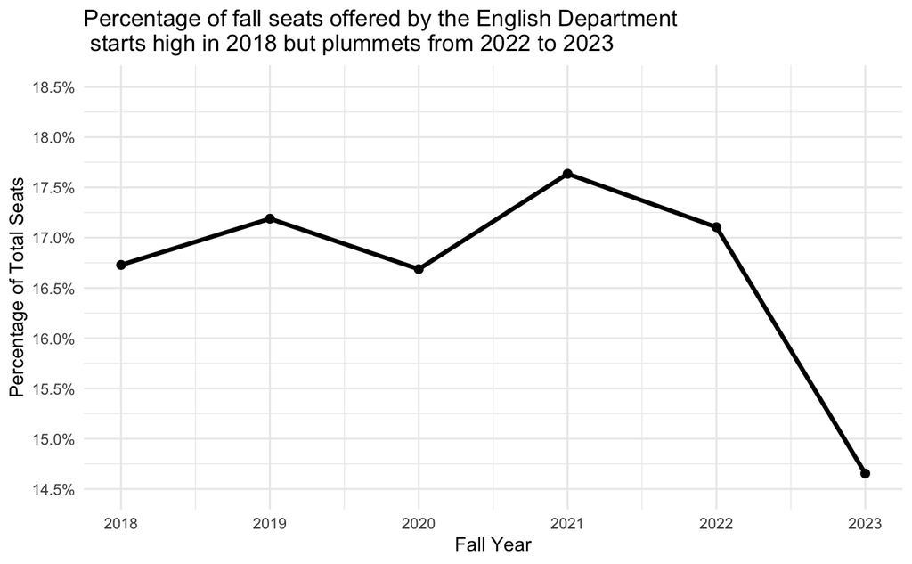

```r
ggplot(seats_by_year_english, aes(x = year, y = percent_of_total, group = 1)) +
  geom_line(size = 1.2) +
  geom_point(size = 2) +
  scale_y_continuous(
     limits = c(14.5,
               max(seats_by_year_english$percent_of_total) * 1.05),
    n.breaks = 10,
    labels = scales::percent_format(scale = 1)
  ) +
  labs(
    title = "Percentage of fall seats offered by the English Department\n starts high in 2018 but plummets from 2022 to 2023",
    x = "Fall Year",
    y = "Percentage of Total Seats"
  ) +
  theme_minimal()
```

** The number of seats offered by the computer science department started gradually increasing in Fall 2018, reaching peak in 2022. However, the department experiences a significant loss of seats in Fall 2023, though it is a much smaller amount/ difference when compared to the English and Journalism departments.

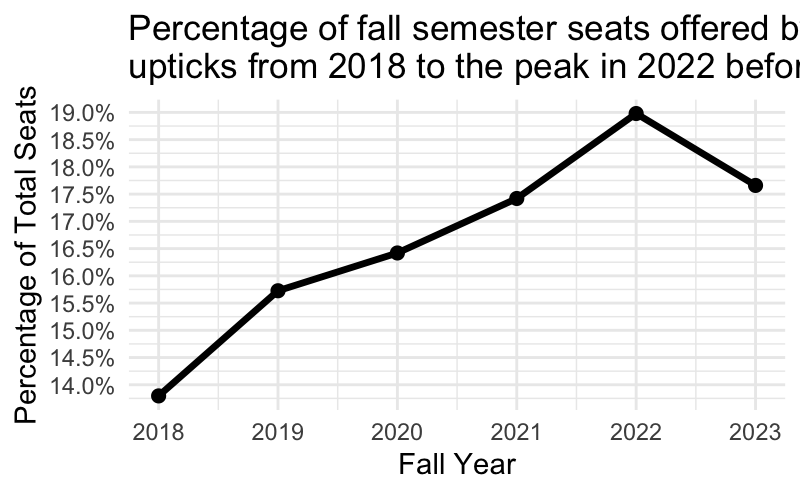

```r
ggplot(seats_by_year_CS, aes(x = year, y = percent_of_total, group = 1)) +
  geom_line(size = 1.2) +
  geom_point(size = 2) +
  scale_y_continuous(
    n.breaks = 10,
    labels = scales::percent_format(scale = 1)
  ) +
  labs(
    title = "Percentage of fall semester seats offered by CS department\nupticks from 2018 to the peak in 2022 before moderately declining in 2023",
    x = "Fall Year",
    y = "Percentage of Total Seats"
  ) +
  theme_minimal()
```

** One major that bridges the gap between STEM and Humanities: Journalism

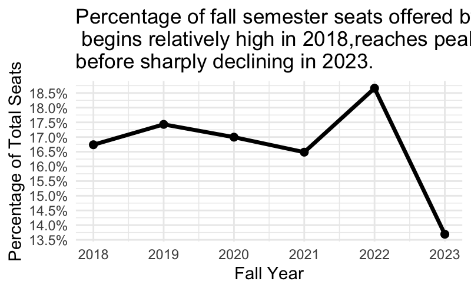

```r
ggplot(seats_by_year_journalism, aes(x = year, y = percent_of_total, group = 1)) +
  geom_line(size = 1.2) +
  geom_point(size = 2) +
  scale_y_continuous(
    n.breaks = 10,
    labels = scales::percent_format(scale = 1)
  ) +
  labs(
    title = "Percentage of fall semester seats offered by Journalism department\n begins relatively high in 2018,reaches peak in 2022\nbefore sharply declining in 2023.",
    x = "Fall Year",
    y = "Percentage of Total Seats"
  ) +
  theme_minimal()
```

Q2: Which departments had the least amount of professors across the years? which ones had the most? Are there any patterns in the results?

```r
prof_to_depart <- courses_fall_spring |>
   group_by(department, term) |>
  summarise(
    total_prof_depart = n_distinct(instructors)
  ) |>
  arrange(desc(total_prof_depart))

seats_to_depart <- courses_fall_spring |>
group_by(department, term) |>
summarise(
  total_seats_depart = sum(seats)
) |>
  arrange(desc(total_seats_depart))
```

Q3: [wildcard] Search the description column for keywords of interest and discuss findings (if a pattern is found, if not keep searching relevant words)

```r
keywords <- c("diversity", "equity", "race", "immigration", "trump", "gender")

chosen_words <- courses_fall_spring |>
  unnest_tokens(word, description) |>
  filter(word %in% keywords) |>
  group_by(start_date, word) |>
  summarise(count = n(), .groups = "drop") |>
  arrange(desc(count))
```

Q4: Is there a change in the mentions of Artificial intelligence in courses?

A4: Through this question we hoped to find out whether the recent uptick in AI usage throughout the world is reflected in the course offerings at UMD. While this data set is two years old there is still a significant increase in the number of courses with a focus on AI. The biggest increase was from the Fall 2022 semester to the Spring 2023 semester where the number of courses more than doubled. This is likely due to the release of ChatGPT in November of 2022. Even though the number of courses dropped again in Fall 2023, it shows how there was a continued interest in AI throughout UMD.

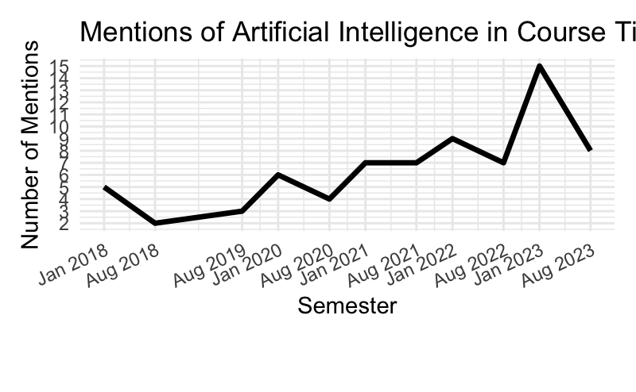

```r
artificial_intelligence <- courses_fall_spring |>
  mutate( title = str_to_upper(title), description = str_to_upper(description)) |>

  filter(
    str_detect(title,"ARTIFICIAL INTELLIGENCE") | str_detect(description, "ARTIFICIAL INTELLIGENCE") | str_detect(title, " AI ") | str_detect(description, " AI ")) |>
  group_by(start_date) |>
summarise(
  semester_total = n(),
  .groups = "drop"
) |>
arrange(desc(start_date))

artificial_intelligence |>
  ggplot() +
  geom_line(aes(x=start_date, y=semester_total), size=1.2)+

labs(title = "Mentions of Artificial Intelligence in Course Title and Description", x= "Semester", y = "Number of Mentions")+
  scale_y_continuous(n.breaks = 15) +
    scale_x_date(
    breaks = artificial_intelligence$start_date,
    date_labels = "%b %Y"
  ) +
  theme_minimal()+
   theme(
    axis.text.x = element_text(angle = 25,  hjust=1),
     plot.margin = margin(10, 10, 35, 10)
  )
```

```r
NA
```